# SSBBBA-Periodical Examination(Resubmission)-2024-04-12

### Q3.E: Analyze Drive Wheels and Fuel System for statistically testing the average price difference, Postulate the appropriate hypothesis and test.

**Hypothesis**

```
        Ho: There is no statistically significant difference in the average price of cars between drive wheel and fuel systems.
        Ha: There is a statistically significant difference in the average price of cars between drive wheel and fuel systems.
```

#### VIS: CarPrice vs (DriveWheels and FuelSystem)

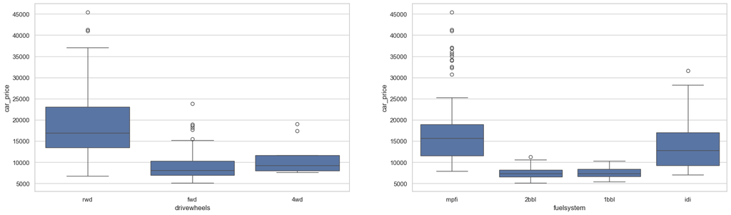

#### ANOVA TABLE: CarPrice ~ Drivewheels and FuelSystem.

|  | df | sum_sq | mean_sq | F | PR(>F) |
| --- | --- | --- | --- | --- | --- |
| drivewheels | 2.0 | 5.274374e+09 | 2.637187e+09 | 79.15850 | 0.00000 |
| fuelsystem | 3.0 | 9.623598e+08 | 3.207866e+08 | 9.62882 | 0.00001 |
| Residual | 199.0 | 6.629739e+09 | 3.331527e+07 | NaN | NaN |

**Inferences:**

1. The variables DriveWheel and fuelsystem are having the different number of degrees of freedom. 2 and 3 respectively.
2. DriveWheel: F value 79.15 and P-value 0.0 suggest to reject the null hypothesis.
3. FuelType: F Value 9.62 and P-value 0.0 also suggest to reject the null hypothesis.
4. Drivewheel F-Value is much higher than to FuelType, This suggests a potentially stronger effect of drive wheel on car price compared to fuel type.
5. In a conclusion: There is a statistically significant difference in the average price of cars between drive wheel and fuel systems.

### Q3.F: Is there any significance difference in average pricing with different body styles. Similarly does engine type plays a significant role in altering the average price. Postulate the appropritate hypothesis and test.

**Hypothesis-1**

```
        Ho: On average, the price of a car isn't affected by its body style.
        Ha: On average, the price of a car is affected by its body style.
```

**Hypothesis-2**

```
        Ho: On average, the price of a car isn't affected by its engine type.
        Ha: On average, the price of a car is affected by its engine type.
```

#### VIS: BodyStye vs car prices AND EngineType Vs CarPrice

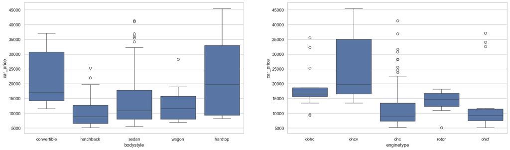

#### ANOVA TABLE: CarPrice ~ BodyStyle and EngineType.

|  | df | sum_sq | mean_sq | F | PR(>F) |
| --- | --- | --- | --- | --- | --- |
| bodystyle | 4.0 | 1.826663e+09 | 4.566658e+08 | 10.25081 | 0.0 |
| enginetype | 4.0 | 2.308158e+09 | 5.770395e+08 | 12.95284 | 0.0 |
| Residual | 196.0 | 8.731652e+09 | 4.454924e+07 | NaN | NaN |

**Inferences:**

1. The variables Bodystyle and Engine type are having the same number of degrees of freedom.
2. Bodystyle: F value 10.25 and P-value 0.0 suggest to reject the null hypothesis.
3. EngineType: F Value 12.95 and P-value 0.0 also suggest to reject the null hypothesis.
4. EngineType F-Value is little higher than to Bodytype.
5. In a conclusion: The average car price is affected by both BodyStyle and EngineType.